# Predicting Exercise Pattern

##Executive summary The goal is to train a model for exercise pattern based on the metrics collected on different wearable devices like jawbone, fitbit and accelerometers tied to their body.

```r
setwd("C:/Users/Karthikeyan/Desktop/R/fitbit")
library("caret")
library("randomForest")
raw=read.csv("pml-training.csv")
```

## Cleaning Data

The data had 160 features. By examining with str, I could see that there are lot of features with NA values. So I removed the column with more than 90% of NA. This resulted in 93 features.

```r
raw_no_na <- raw[,colSums(is.na(raw))<1000]
```

Columns like X, user_name, time-stamp columns and columns with no real values were removed. This left with 79 features. I faced trouble with factor variables and out of memory with the data obtained so far and hence decided to clean further.

```r
removecol= c("X","user_name","raw_timestamp_part_1","raw_timestamp_part_2","cvtd_timestamp","kurtosis_yaw_belt","skewness_yaw_belt","amplitude_yaw_belt","kurtosis_yaw_dumbbell","skewness_yaw_dumbbell","amplitude_yaw_dumbbell","kurtosis_yaw_forearm","skewness_yaw_forearm","amplitude_yaw_forearm")

clean_data= raw_no_na[, !(colnames(raw_no_na) %in% removecol)]
```

The factor variables are then converted into character then to numeric. It is also found that most of the factor variables had empty values. So they are also filtered.

Let cols be list of factor columns

```r
cols=c("new_window","kurtosis_roll_belt","kurtosis_picth_belt","skewness_roll_belt","skewness_roll_belt.1","max_yaw_belt","min_yaw_belt","kurtosis_roll_dumbbell","kurtosis_picth_dumbbell","skewness_roll_dumbbell","skewness_pitch_dumbbell","max_yaw_dumbbell","min_yaw_dumbbell","kurtosis_roll_forearm","kurtosis_picth_forearm","skewness_roll_forearm","skewness_pitch_forearm","max_yaw_forearm","min_yaw_forearm","kurtosis_roll_arm","kurtosis_picth_arm","kurtosis_yaw_arm","skewness_roll_arm","skewness_pitch_arm","skewness_yaw_arm")

clean_data[cols] <- lapply(clean_data[cols], as.character)
clean_data[cols] <- lapply(clean_data[cols], as.numeric)
clean_data$classe = as.numeric(clean_data$classe)
clean_data <- clean_data[,colSums(is.na(clean_data))<1000]
```

Now we are left with 54 features.

## Exploratory Analysis

Created paired (fig-1) plots for classe and few parameters but could not see any pattern or correlation.

pairs(~roll_belt+total_accel_belt+yaw_arm+total_accel_dumbbell+total_accel_forearm+classe, data=clean_data)

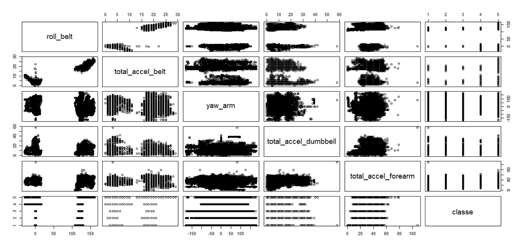

```r
partition=createDataPartition(y=clean_data$classe, p=0.7,list=F)
train=clean_data[partition,]
test=clean_data[-partition,]
mrf = randomForest(classe~.,data=train, na.action=na.omit)
```

##Model Analysis Result is: Number of trees: 500 No. of variables tried at each split: 17 Mean of squared residuals: 0.01606878 % Var explained: 99.26

The plot of the model shows great decrease in error as the number of trees grow.

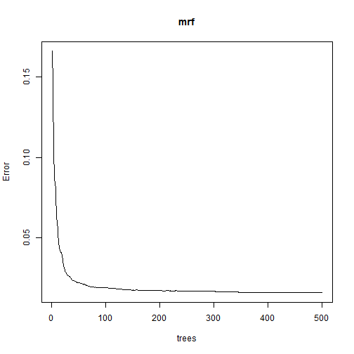

```r
    plot(mrf)
```

```r
    pred = round(predict(mrf, test))
    accuracy = sum(pred==test$classe)/nrow(test)*100
    accuracy
```

```
## [1] 98.98
```